# MS_dataAnalysis

Ben Helms

2026-04-28

### **Abstract**

##### In my second chapter, I investigate the predictive accuracy of single-scan TLS-based models when predicting the fuel loads of five surface fuel components: fine dead surface fuels, large-diameter down dead woody fuels, herbaceous fuels, live woody fuels, and total surface fuels. Three predictive models (random forest, elastic net, and multiple linear regression via leaps and bounds selection) were developed for each component using 166 TLS point cloud-derived predictor variables and a 10-repeat 5-fold cross-validation scheme. My results show that predictions were relatively unbiased; however, normalized root mean square error (NRMSE; 60%-548%) and explanatory power (R<sup>2</sup> = -11.16-0.37) varied across modeling approaches, fuel components, and cross‑validation runs. In general, the elastic net model produced the lowest errors, and errors across modeling approaches were smallest and most consistent for fine dead surface fuels, but large and highly variable for large-diameter down dead wood. These findings indicate that TLS-based models can be error-prone and inconsistent when predicting fine-scale fuel loading in Colorado Front Range dry conifer forests and highlight the need for additional research to improve accuracy.

### **Chapter 1 data analysis - Characterizing forest structure in dry conifer forests of the Colorado Front Range with Terrestrial Laser Scanning**

#### **Table 1.** Plot-level summary statistics describing the 74 plots used as validation data in this study. Measurements were performed with manual field-based methods, and only trees with a DBH of 12.7 cm or greater were measured.

| Attribute | Min | Mean | Max | SD | CV (%) |
| --- | --- | --- | --- | --- | --- |
| DBH (cm) | 16.0 | 30.9 | 81.8 | 10.1 | 33 |
| Height (m) | 5.6 | 12.1 | 21.9 | 3.5 | 29 |
| CBH (m) | 0.7 | 3.5 | 9.2 | 2.0 | 56 |
| Tree density (trees ha<sup>-1</sup>) | 25.0 | 282.5 | 1038.0 | 207.1 | 73 |
| Basal area (m<sup>2</sup> ha<sup>-1</sup>) | 2.0 | 19.0 | 42.5 | 9.9 | 52 |

#### **Table 2.** Summary of correlation coefficient (R), absolute error, and bias for diameter at breast height (DBH), height, canopy base height (CBH), tree density, and basal area for single-scan and multi-scan approaches.

#### Single-scan correlation and error

Correlation coefficient (R) between single-scan and manual estimates

| Statistic | DBH (cm) | Height (m) | CBH (m) | Tree density (trees ha<sup>-1</sup>) | Basal area (m<sup>2</sup> ha<sup>-1</sup>) |
| --- | --- | --- | --- | --- | --- |
| R | 0.63 | 0.77 | 0.68 | 0.76 | 0.48 |

Single-scan absolute error

| Statistic | DBH (cm) | Height (m) | CBH (m) | Tree density (trees ha<sup>-1</sup>) | Basal area (m<sup>2</sup> ha<sup>-1</sup>) |
| --- | --- | --- | --- | --- | --- |
| Min | 0.00 | 0.00 | 0.00 | 0.00 | 0.00 |
| Median | 3.15 | 1.30 | 0.90 | 74.00 | 7.50 |
| Max | 27.20 | 9.40 | 7.30 | 618.00 | 90.30 |

Single-scan bias

| Statistic | DBH (cm) | Height (m) | CBH (m) | Tree density (trees ha<sup>-1</sup>) | Basal area (m<sup>2</sup> ha<sup>-1</sup>) |
| --- | --- | --- | --- | --- | --- |
| Min | −27.20 | −9.40 | −7.30 | −271.00 | −9.80 |
| Median | 2.40 | −1.30 | −0.90 | 25.00 | 6.80 |
| Max | 19.50 | 2.00 | 0.40 | 618.00 | 90.30 |

#### Multi-scan correlation and error

Correlation coefficient (R) between multi-scan and manual estimates

| Statistic | DBH (cm) | Height (m) | CBH (m) | Tree density (trees ha<sup>-1</sup>) | Basal area (m<sup>2</sup> ha<sup>-1</sup>) |
| --- | --- | --- | --- | --- | --- |
| R | 0.77 | 0.76 | 0.63 | 0.69 | 0.42 |

Multi-scan absolute error

| Statistic | DBH (cm) | Height (m) | CBH (m) | Tree density (trees ha<sup>-1</sup>) | Basal area (m<sup>2</sup> ha<sup>-1</sup>) |
| --- | --- | --- | --- | --- | --- |
| Min | 0.00 | 0.10 | 0.00 | 0.00 | 0.10 |
| Median | 2.80 | 1.15 | 0.80 | 62.00 | 6.65 |
| Max | 36.50 | 11.20 | 6.00 | 2,224.00 | 233.00 |

Multi-scan bias

| Statistic | DBH (cm) | Height (m) | CBH (m) | Tree density (trees ha<sup>-1</sup>) | Basal area (m<sup>2</sup> ha<sup>-1</sup>) |
| --- | --- | --- | --- | --- | --- |
| Min | −36.50 | −11.20 | −6.00 | −173.00 | −6.20 |
| Median | 1.75 | −0.60 | −0.80 | 49.50 | 6.40 |
| Max | 18.10 | 2.50 | 0.90 | 2,224.00 | 233.00 |

#### **Table 3.** The percentage of single-scan and multi-scan plots with absolute percent errors that meet the 10% maximum error threshold outlined by the US Forest Service for plot-based field surveys of diameter at breast height (DBH), height, canopy base height (CBH), tree density, and the combination of all four parameters.

| Approach | DBH (%) | Height (%) | CBH (%) | Tree density (%) | Total (%) |
| --- | --- | --- | --- | --- | --- |
| Single-scan | 46 | 41 | 18 | 20 | 4 |
| Multi-scan | 53 | 50 | 20 | 26 | 3 |

#### **Table 4.** Results from linear mixed‑effects models evaluating the relationship between each occlusion metric (total occlusion; occlusion below 2 m) and the absolute percent error (APE) of each forest structure parameter.

| Predictor | Estimate | P-value | R<sup>2</sup> |
| --- | --- | --- | --- |
| DBH |  |  |  |
| Occlusion below 2 m | 1.496 | 0.002 | 0.239 |
| Total occlusion | 0.150 | 0.222 | 0.073 |
| Height |  |  |  |
| Occlusion below 2 m | 2.087 | 0.003 | 0.205 |
| Total occlusion | 0.017 | 0.730 | 0.134 |
| CBH |  |  |  |
| Occlusion below 2 m | 2.257 | 0.040 | 0.338 |
| Total occlusion | 0.048 | 0.497 | 0.350 |
| Tree density |  |  |  |
| Occlusion below 2 m | 0.688 | 0.003 | 0.114 |
| Total occlusion | −0.003 | 0.852 | 0.129 |
| Basal area |  |  |  |
| Occlusion below 2 m | 0.344 | 0.000 | 0.210 |
| Total occlusion | 0.005 | 0.439 | 0.093 |

#### **Fig. 1.** Box and whisker plots comparing single- and multi-scan absolute percent error and relative bias for plot-level estimates of diameter at breast height (DBH), height, canopy base height (CBH), tree density, and basal area. Text lists the median absolute percent error and median relative bias. Significant (alpha 0.05) one-way ANOVA or Wilcoxon signed-rank tests evaluating differences between the scan approaches are denoted by an asterisk.

#### **Absolute Percent Error (APE)**

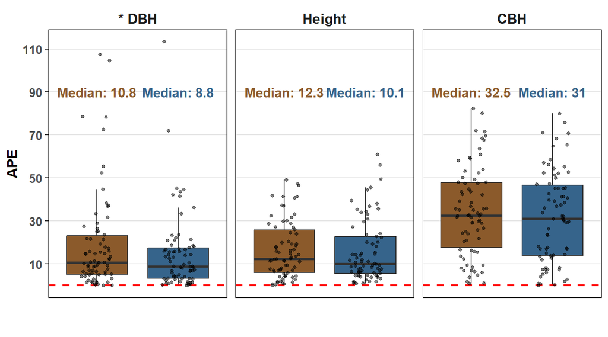

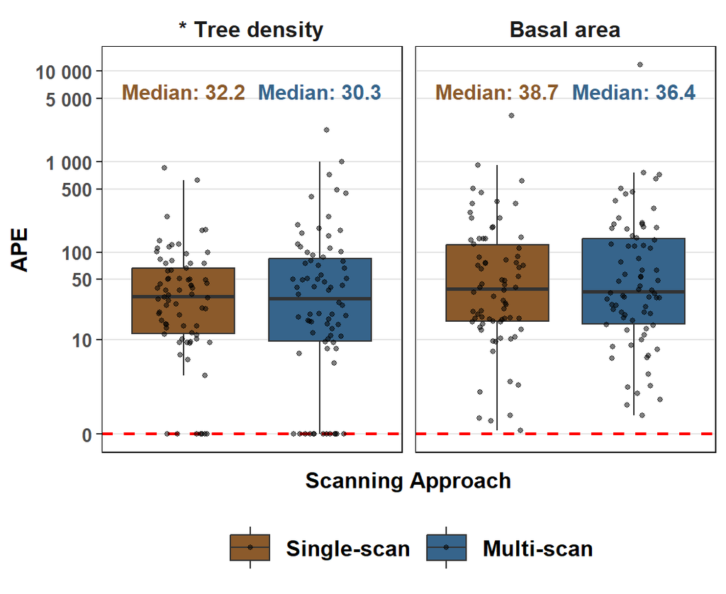

#### **Relative bias (bias%)**

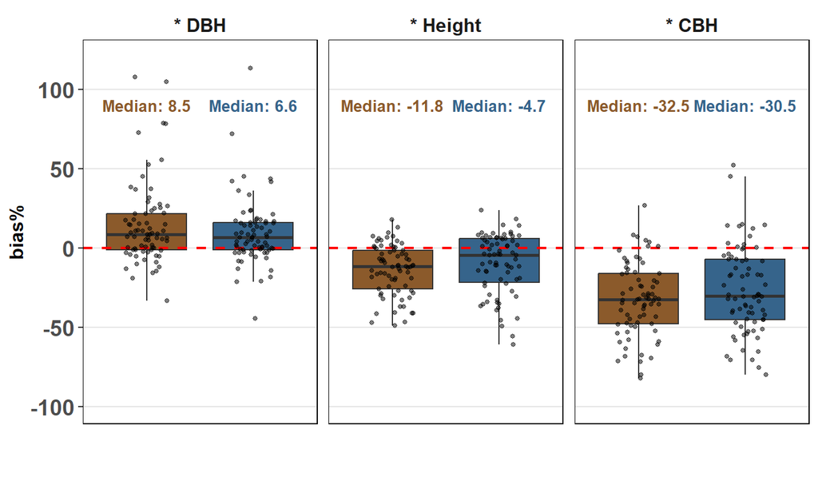

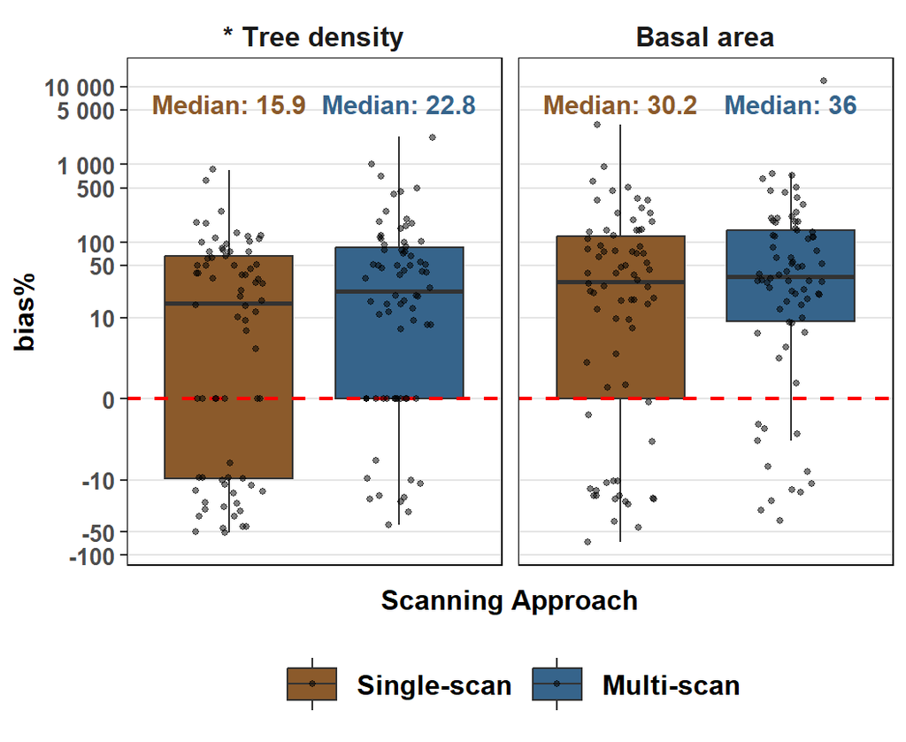

### **Chapter 2 data analysis - Predicting fine-scale surface fuel loading with Terrestrial Laser Scan metrics in dry conifer forests of the Colorado Front Range**

#### **Table 1.** Summary statistics describing the minimum, mean, median, maximum, standard deviation, and coefficient of variation of destructively sampled surface fuel loads.

| Statistic | Fine dead surface fuels | Large-diameter DDW | Herbaceous fuels | Live woody fuels | Total surface fuels |
| --- | --- | --- | --- | --- | --- |
| Min (kg m<sup>-2</sup>) | 0.05 | 0.00 | 0.00 | 0.00 | 0.12 |
| Mean (kg m<sup>-2</sup>) | 0.82 | 1.08 | 0.03 | 0.43 | 2.38 |
| Median (kg m<sup>-2</sup>) | 0.73 | 0.17 | 0.01 | 0.08 | 1.38 |
| Max (kg m<sup>-2</sup>) | 2.15 | 46.71 | 0.22 | 8.29 | 47.17 |
| SD (kg m<sup>-2</sup>) | 0.49 | 4.95 | 0.05 | 1.11 | 5.06 |
| CV (%) | 59.00 | 457.00 | 144.00 | 260.00 | 213.00 |

#### **Table 2.** Performance metrics for predictions of each surface fuel component using *random forest*, *elastic net*, and *leaps and bounds* models. Metrics include the mean and standard deviation for R<sup>2</sup>, root mean square error (RMSE), normalized root mean square error (NRMSE), and bias calculated from each cross-validation run using 20% of data withheld from model development.

Performance metrics for predictions of each surface fuel component using random forest, elastic net, and leaps and bounds models

| Fuel component | Mean R<sup>2</sup> | SD R<sup>2</sup> | Mean RMSE (kg m<sup>-2</sup>) | SD RMSE (kg m<sup>-2</sup>) | Mean NRMSE (%) | SD NRMSE (%) | Mean Bias (kg m<sup>-2</sup>) | SD Bias (kg m<sup>-2</sup>) |
| --- | --- | --- | --- | --- | --- | --- | --- | --- |
| Random Forest |  |  |  |  |  |  |  |  |
| Fine dead surface fuels | −0.08 | 0.24 | 0.49 | 0.05 | 60.31 | 8.50 | 0.00 | 0.10 |
| Large-diameter DDW | −4.49 | 9.15 | 3.88 | 2.46 | 404.84 | 249.18 | 0.08 | 0.83 |
| Herbaceous fuels | 0.37 | 0.22 | 0.04 | 0.01 | 110.28 | 25.25 | 0.00 | 0.01 |
| Live woody fuels | −2.36 | 7.44 | 0.99 | 0.48 | 252.35 | 121.94 | −0.02 | 0.30 |
| Total surface fuels | −1.71 | 3.77 | 4.23 | 2.45 | 171.13 | 72.47 | 0.03 | 0.97 |
| Elastic Net |  |  |  |  |  |  |  |  |
| Fine dead surface fuels | −0.06 | 0.12 | 0.49 | 0.05 | 59.89 | 7.03 | 0.00 | 0.10 |
| Large-diameter DDW | −0.96 | 2.17 | 3.74 | 3.28 | 310.63 | 95.82 | −0.02 | 0.96 |
| Herbaceous fuels | 0.24 | 0.21 | 0.04 | 0.01 | 122.47 | 26.84 | 0.00 | 0.01 |
| Live woody fuels | −0.67 | 3.00 | 0.90 | 0.56 | 206.97 | 75.97 | 0.00 | 0.28 |
| Total surface fuels | −0.48 | 0.91 | 4.14 | 2.95 | 156.52 | 66.61 | −0.03 | 1.03 |
| Leaps and Bounds |  |  |  |  |  |  |  |  |
| Fine dead surface fuels | −0.12 | 0.18 | 0.50 | 0.06 | 61.60 | 8.19 | 0.01 | 0.10 |
| Large-diameter DDW | −11.16 | 31.48 | 4.75 | 2.70 | 548.11 | 409.98 | −0.13 | 1.11 |
| Herbaceous fuels | 0.20 | 0.26 | 0.04 | 0.01 | 125.12 | 29.21 | 0.00 | 0.01 |
| Live woody fuels | −3.58 | 9.18 | 1.11 | 0.45 | 292.43 | 131.21 | −0.02 | 0.33 |
| Total surface fuels | −3.28 | 8.79 | 4.88 | 2.66 | 201.59 | 97.81 | −0.15 | 1.15 |

#### **Fig. 1.** Box and whisker plots displaying the cross-validated variable importance for *random forest* models and coefficient magnitudes for *elastic net* and *leaps and bounds* models when predicting each surface fuel component. Only variables selected in at least 75% of cross-validation runs were included. Empty plots for elastic net and leaps and bounds show that no variable was selected in at least 75% of runs.

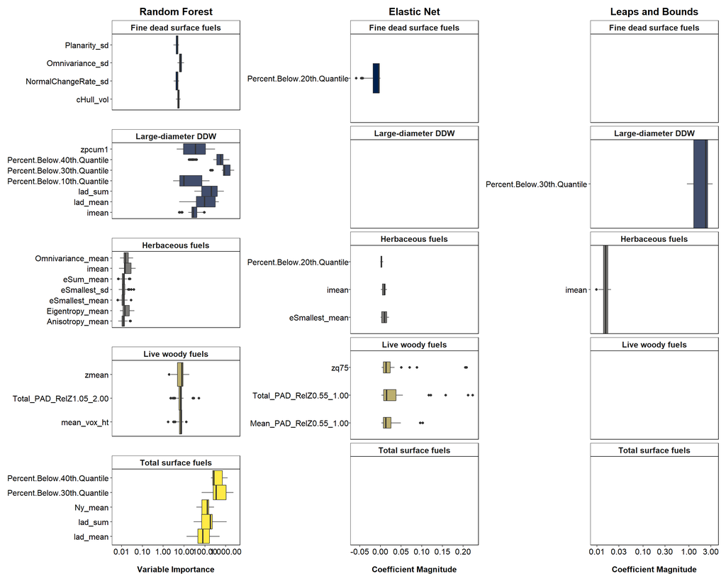

#### **Fig. 2.** Box and whisker plots displaying the distribution of NRMSEs across the 50 cross validation runs for each model.

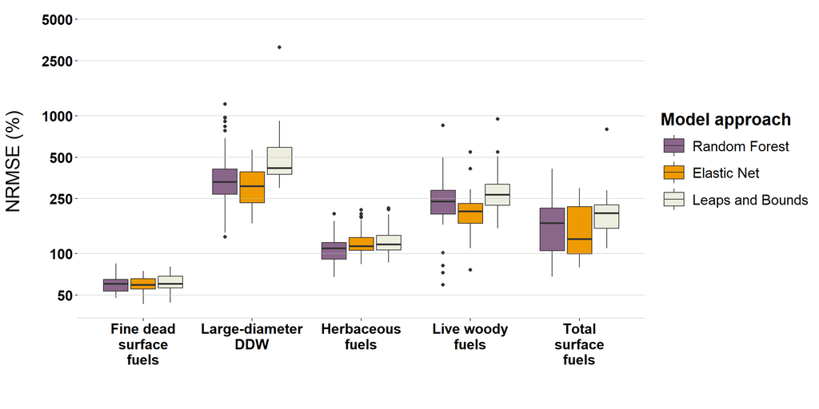